# A3: SPL Library Checkouts

Aaron He

2023-03-08

### Introduction

In this report, the data: MaterialType, Checkouts, and CheckoutType, in the dataset would be analyzed. My purpose is to examine the degree of popularity in three material types, the popularity among all checkout types, and the difference of checkouts between book and ebook material types based on the avaliable data. Therefore, I chose the data, Dataset with items checked out at least 10 times a month from 2017-20203, provided by Seattle Public library, which is what I want to analyze.

### Summary Information

According to the data, Dataset with items checked out at least 10 times a month from 2017-20203, provided by Seattle Public library. I found that this dataset contains 816354 different observations, and 12 features or factors we analyze. Moreover, there are 32 different material types, and ebook type only contains 201049. Besides, the average number of checkouts are 23.4773995.

### The Dataset

> **Who collected/published the data?**

The data was published by Seattle Public Library.

> **What are the parameters of the data (dates, number of checkouts, kinds of books, etc.)?**

The parameters of the data include the way of usage, the website of checkout, the checkout type of book, date of checkout, the number of checkout, the title of book, the creator of book, the subject of book, the publisher of book, and the publish year of book.

> **How was the data collected or generated?**

Checkout data comes from multiple current and historical sources. For digital items, the media vendors: Overdrive, hoopla, Freegal, and RBDigital provide usage data.For historical physical item checkouts from April 2005 to September 30, 2016, the source of this data is the Legrady artwork data archives. For October 1 2016 to present, the source is the Horizon ILS.

> **Why was the data collected?**

This collected data can help Seattle Public Library better understand how its collection is being used and to inform decision-making around collection development, programming, and outreach. Also, this data can encourage analysis and exploration by researchers, analysts, and members of the public.

> **What, if any, ethical questions do you need to consider when working with this data?**

When working with this data, it is essential to consider the privacy and confidentiality of library users. Even though dataset does not include any personally identifiable information, it does contain information on the titles that individuals have checked out.Therefore, researchers or analysts should care about not to draw conclusions about individuals or groups based on this data.

### First Trends Over Time Chart

The chart was included to visually represent the popularity of three material types in the dataset. It provides a convenient and obvious way to understand the distribution of checkouts across three material types and identify any notable patterns or trends.

Overall, the chart provides a useful summary of the popularity of three material types in the dataset and highlights some interesting patterns in the data.

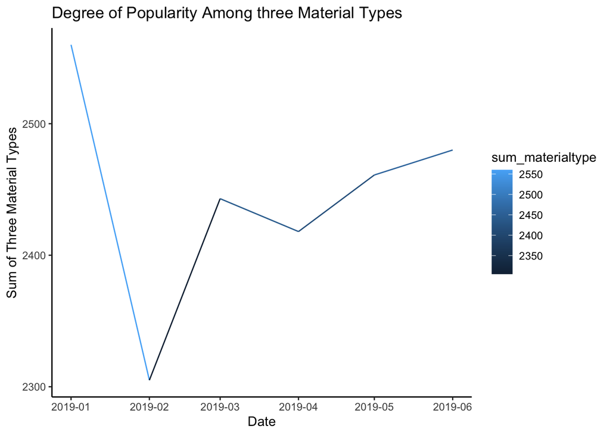

### Second Trends Over Time Chart

The chart was created to visually display the degree of popularity among checkout types in the dataset. By grouping the data by “CheckoutType” and counting the number of occurrences of each type, we can get a sense of which checkout types are more commonly used and which are less commonly used.

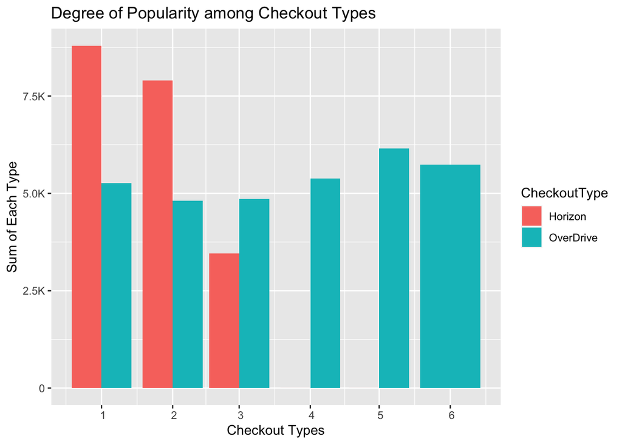

### Third Trends Over Time Chart

The chart was included to compare the checkouts/popularity of two different material types - books and ebooks - in the dataset. By filtering the data to only include rows where the “MaterialType” is either “BOOK” or “EBOOK”, we can get a sense of the difference in popularity between these two types of materials.

Looking at the scatter plot, we can see that books are still more popular than ebooks in terms of the total number of checkouts. However, the difference in popularity between these two types of materials is not as significant as the difference in popularity between different checkout types that we saw in the previous chart. This suggests that both physical and digital materials are important to library patrons, and libraries may need to allocate resources to both types of collections.

The pattern that emerges from this chart is that books are still more popular than ebooks, but ebooks still account for a significant portion of the total checkouts for these two material types. This suggests that libraries should consider investing in both physical and digital collections to meet the needs and preferences of their patrons.

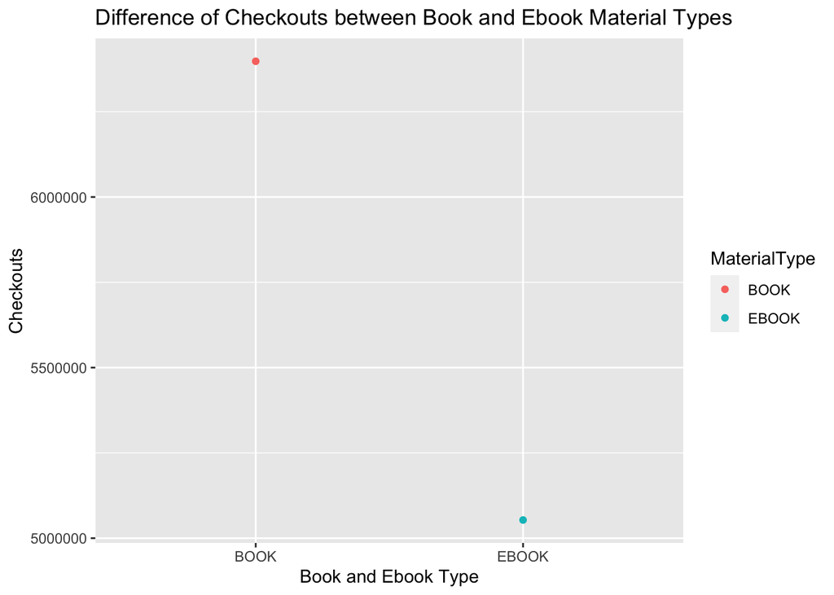